# Stroop_Effect Project

In a Stroop task, participants are presented with a list of words, with each word displayed in a color of ink. The participant’s task is to say out loud the color of the ink in which the word is printed. The task has two conditions: a congruent words condition, and an incongruent words condition. In the congruent words condition, the words being displayed are color words whose names match the colors in which they are printed: for example RED, BLUE. In the incongruent words condition, the words displayed are color words whose names do not match the colors in which they are printed: for example PURPLE, ORANGE. In each case, we measure the time it takes to name the ink colors in equally-sized lists. Each participant will go through and record a time from each condition.

**Question 1:** What is our independent variable? What is our dependent variable?

**Answer:** Independent variable is *Words Condition*

```
There are two words condition-
        1.Congruent word condition
        2.Incongruent word condition
```

Dependent variable is *Time(in second)* that participant takes to name the ink colors in equal-sized list.

**Question 2:** What is an appropriate set of hypotheses for this task? What kind of statistical test do you expect to perform?Justify your choices.

**Answer:** An appropriate set of hypotheses for this task will be:

```
           1.Null Hypothesis(H0):μi - μc = 0
            ie. There is no significant difference in average time(second) that population take to name ink
                colors for two differrent words condition(Congruence and Incongruence).

           2.Alternative Hypothesis(Ha):μi - μc ≠ 0
            ie. There is  significant difference in average time(second) that population take to name ink
                colors for two differrent words condition(Congruence and Incongruence).

            where μi : population mean of  Incongruence word condition values(Time)
                  μc : population mean of  Congruence word condition values(Time)


         I would like to perform dependent two tail T-test.

         1.I select T-test Because  population parameter that is Population  standard deviation and mean is  not Known.
           So,Z-test can't be performed.
         2.I choose T-test of dependent type because both words condition experiment is taken by each participant.
           ie. our  sample is same for both experiment.

          T-test has disadvantages like in this case,a participant may get some expreience due to first experiment
          so,he/she can reponse quickly in next experiment and reduce the respose time(sec) for second experiment.
```

**Question 3:** Report some descriptive statistics regarding this dataset. Include at least one measure of central tendency and at least one measure of variability.

**Answer:** Each Sample Size : 24

[output not shown]

```python
#Load Libraries
import pandas as pd
import numpy as np
from matplotlib import pyplot as plt
import math
```

```python
#read data
stroop_effect = pd.read_csv("stroopdata.csv")

#display data
print(stroop_effect)
```

```
    Congruent  Incongruent
0      12.079       19.278
1      16.791       18.741
2       9.564       21.214
3       8.630       15.687
4      14.669       22.803
5      12.238       20.878
6      14.692       24.572
7       8.987       17.394
8       9.401       20.762
9      14.480       26.282
10     22.328       24.524
11     15.298       18.644
12     15.073       17.510
13     16.929       20.330
14     18.200       35.255
15     12.130       22.158
16     18.495       25.139
17     10.639       20.429
18     11.344       17.425
19     12.369       34.288
20     12.944       23.894
21     14.233       17.960
22     19.710       22.058
23     16.004       21.157
```

```python
#Describe data
print(stroop_effect.describe())
```

```
       Congruent  Incongruent
count  24.000000    24.000000
mean   14.051125    22.015917
std     3.559358     4.797057
min     8.630000    15.687000
25%    11.895250    18.716750
50%    14.356500    21.017500
75%    16.200750    24.051500
max    22.328000    35.255000
```

```python
"""Find range of two different data(Cogruence and Incongruence) """

#max_cong contains maximum time(sec) of Congruent
#max_incong contains maximum time(sec) of Incongruent
max_cong,max_incong = stroop_effect.max()

#min_cong contains maximum time(sec) of Congruent
#min_incong contains maximum time(sec) of incongruent
min_cong,min_incong = stroop_effect.min()

#range_cong contains range of Congruent
#range_incong contains range of Incongruent
range_cong = max_cong - min_cong
range_incong = max_incong - min_incong

print("Range of Congruent:" + str(range_cong))
print("Range of Incongruent:" + str(range_incong))
```

```
Range of Congruent:13.698
Range of Incongruent:19.568
```

```python
#Find median of sample data

median_cong = stroop_effect['Congruent'].median()
print("Median Of Congruent:" + str(median_cong))

median_incong = stroop_effect['Incongruent'].median()
print("Median Of Incongruent:" + str(median_incong))
```

```
Median Of Congruent:14.3565
Median Of Incongruent:21.0175
```

**Question 4:** Provide one or two visualizations that show the distribution of the sample data. Write one or two sentences noting what you observe about the plot or plots. **Answer:** 1.The distribution of Congruent data is between 8 to 24 seconds but the distribution of Incongruent data is between 14 to 36 seconds.

```
        2.The time(in second) for each participant in Incongruent data is greater than corresponding time(in second)
          in Congruent data.
```

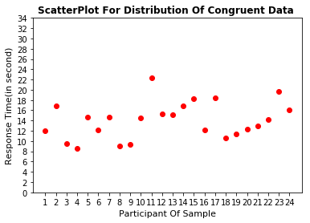

```python
#ScatterPlot Is Used to show the distribution sample data because there are less number of element in sample,So It provide
#better Visualizations
x = range(1,25,1)
plt.scatter(x,stroop_effect['Congruent'],color = 'r')
plt.title('ScatterPlot For Distribution Of Congruent Data ', size=12, fontweight='bold')
plt.xlabel("Participant Of Sample",size = '11')
plt.ylabel("Response Time(in second)",size = '11')

plt.xticks(np.arange(1,25,1))
plt.yticks(np.arange(0,36,2))
plt.show()
```

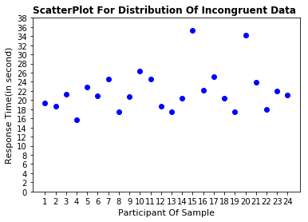

```python
#ScatterPlot Is Used to show the distribution sample data because there are less number of element in sample,So It provide
#better Visualizations
x = range(1,25,1)
plt.scatter(x,stroop_effect['Incongruent'],color = 'b')
plt.title('ScatterPlot For Distribution Of Incongruent Data ', size=12, fontweight='bold')
plt.xlabel("Participant Of Sample",size = '11')
plt.ylabel("Response Time(in second)",size = '11')

plt.xticks(np.arange(1,25,1))
plt.yticks(np.arange(0,40,2))
plt.show()
```

**Question 5:** Now, perform the statistical test and report your results. What is your confidence level and your critical statistic value? Do you reject the null hypothesis or fail to reject it? Come to a conclusion in terms of the experiment task. Did the results match up with your expectations?

**Answer:** This is dependent two tail T-test.And

```
       Here, Degree of freedom : n-1 = 24 -1 = 23

       Consider α-level : 0.05 or 5%
       ie. confidence interval : 95%

       t_critical : 2.069     #value seen from t-table..



       Now, t_statistic is far greater than t-critical.

            ie. t > t_critical

        Therefore,i will reject the null hypothesis. There is  significant difference in average time(second)
        that population take to name ink colors for two differrent words condition(Congruence and Incongruence).


        Yes,Result match up with my expectations because if ink colors and words don't match.It's hard to tell the
        ink color quickly.and it's happen to me as well. But we can do that perfectly by doing practice.
```

```python
#point estimate for μi - μc

mean_cong = stroop_effect['Congruent'].mean()
mean_incong = stroop_effect['Incongruent'].mean()

mean_cong = round(mean_cong,2)
mean_incong = round(mean_incong,2)

#pe is point estimate for μi - μc
pe = mean_incong - mean_cong
pe = round(pe,2)
```

```python
#calculate standard deviation for difference


#stroop_effect['df] where df is coloumn which contain difference of corresponding element between
#Incongruent and Congruent
stroop_effect['df'] = stroop_effect['Incongruent'] - stroop_effect['Congruent']


#md is coloumn of mean deviation in Stroop_effect.csv
stroop_effect['md'] = stroop_effect['df'] - stroop_effect['df'].mean()

#smd is square mean deviation of DF
stroop_effect['smd'] = stroop_effect['md']**2
print("After Updating The stroopdata.csv\n")
print(stroop_effect)

#no_element is sample size
no_element = len(stroop_effect['Congruent'])

#sdd is sample standard deviation of differnce
ssd = math.sqrt(stroop_effect['smd'].sum()/(no_element - 1))
ssd = round(ssd,2)

print("\nPoint estimate for μi - μc : " + str(pe))
print("Sample Standard deviation : " + str(ssd))
```

```
After Updating The stroopdata.csv

    Congruent  Incongruent      df         md         smd
0      12.079       19.278   7.199  -0.765792    0.586437
1      16.791       18.741   1.950  -6.014792   36.177719
2       9.564       21.214  11.650   3.685208   13.580760
3       8.630       15.687   7.057  -0.907792    0.824086
4      14.669       22.803   8.134   0.169208    0.028631
5      12.238       20.878   8.640   0.675208    0.455906
6      14.692       24.572   9.880   1.915208    3.668023
7       8.987       17.394   8.407   0.442208    0.195548
8       9.401       20.762  11.361   3.396208   11.534231
9      14.480       26.282  11.802   3.837208   14.724168
10     22.328       24.524   2.196  -5.768792   33.278957
11     15.298       18.644   3.346  -4.618792   21.333236
12     15.073       17.510   2.437  -5.527792   30.556481
13     16.929       20.330   3.401  -4.563792   20.828194
14     18.200       35.255  17.055   9.090208   82.631888
15     12.130       22.158  10.028   2.063208    4.256829
16     18.495       25.139   6.644  -1.320792    1.744491
17     10.639       20.429   9.790   1.825208    3.331385
18     11.344       17.425   6.081  -1.883792    3.548671
19     12.369       34.288  21.919  13.954208  194.719930
20     12.944       23.894  10.950   2.985208    8.911469
21     14.233       17.960   3.727  -4.237792   17.958878
22     19.710       22.058   2.348  -5.616792   31.548349
23     16.004       21.157   5.153  -2.811792    7.906172

Point estimate for μi - μc : 7.97
Sample Standard deviation : 4.86
```

```python
#Calculate T-statistic
# t = (μi - μc)/( ssd/√n) where n is sample size and ssd is sample standard deviation

t = pe/(ssd/math.sqrt(24))
t = round(t,2)
print('Value Of t : '  + str(t))
```

```
Value Of t : 8.03
```

*References*

```
   https://s3.amazonaws.com/udacity-hosted-downloads/t-table.jpg
```